# Temperature

Atribút temperature reprezentuje teplotu vzduchu meranú v °C.

```r
load('.Rdata')

summary(mandatory_data$TMP)
```

```
##    Min. 1st Qu.  Median    Mean 3rd Qu.    Max.    NA's
## -25.000   2.900  10.000   9.906  17.000  37.300       3
```

```r
mandatory_data['TMP'] %>% profiling_num()
```

| variable | mean | std_dev | variation_coef | p_01 | p_05 | p_25 | p_50 | p_75 | p_95 | p_99 | skewness | kurtosis | iqr | range_98 | range_80 |
| --- | --- | --- | --- | --- | --- | --- | --- | --- | --- | --- | --- | --- | --- | --- | --- |
| TMP | 9.906381 | 9.578574 | 0.9669096 | -12 | -5 | 2.9 | 10 | 17 | 26 | 31 | 0.0008356282 | 2.607313 | 14.1 | [-12, 31] | [-2, 22.6] |

```r
getmode(na.omit(mandatory_data$TMP)) # modus
```

```
## [1] 1
```

```r
var(mandatory_data$TMP, na.rm = T) # rozptyl
```

```
## [1] 91.74908
```

```r
max(mandatory_data$TMP, na.rm = T) - min(mandatory_data$TMP, na.rm = T) # variacne rozpatie
```

```
## [1] 62.3
```

```r
# Interquartile range and outliers
Q1 <- quantile(mandatory_data$TMP, 0.25, na.rm = T) # 25% hodnot je mensich a 75% vacsich
Q3 <- quantile(mandatory_data$TMP, 0.75, na.rm = T) # 75% hodnot je mensich a 25% vacsich
IQR <- IQR(mandatory_data$TMP, na.rm = T) # interquartile range
IQR_dev <- IQR/2

# odlahle hodnoty
length(which(mandatory_data$TMP < (Q1 - 1.5*IQR)))
```

```
## [1] 154
```

```r
length(which(mandatory_data$TMP > (Q3 + 1.5*IQR)))
```

```
## [1] 0
```

```r
# extremne hodnoty
length(which(mandatory_data$TMP < (Q1 - 3*IQR)))
```

```
## [1] 0
```

```r
length(which(mandatory_data$TMP > (Q3 + 3*IQR)))
```

```
## [1] 0
```

Hodnota výberového mediánu je 10 a hodnota výberového priemeru 9.9. Rozdiel hodnôt je iba 0.1 teda výberový priemer môžme považovať za dobrý odhad strednej hodnoty.

Modus - najčastejšia hodnota teploty je 1.

Výberový rozptyl je 91.749, čo je stredná kvadratická odchýlka hodnôt od výberového priemeru. Vyjadruje ako veľmi sú hodnoty rozptýlené od priemeru. Čím je väčší, tým viac sa hodnoty odchyľujú od priemeru.

Výberová smerodajná odchýlka je 9.578574. Vyjadruje kvadratický priemer odchýlok jednotlivých hodnôt teploty od ich aritmetického priemeru. Jej hodnota môže byť vyššia v porovnaní s medzikvartilovou odchýlkou pretože v dátach sa nachádza niekoľko odľahlých hodnôt.

Medzikvartilová odchýlka (IQR/2) je 7.05, čo je v porovnaní so smerodajnou odchýlkou o niečo menej.

Variačné rozpätie je 62.3. Daná hodnota predstavuje rozdiel medzi maximálnou a minimálnou nameranou hodnotou teploty. Jeho veľkosť závisí iba od krajných hodnôt, pričom v tomto prípade spodná hranica patrí medzi odľahlé hodnoty. Preto variačné rozpätie mimo odľahlých hodnôt bude o niečo menšie.

Variačný koeficient je mierou relatívnej variability definovaný ako podiel smerodajnej odchýlky a aritmetického priemeru. Variačný koeficient teploty je 0.9669 (97%), čo je dosť veľa a teda dáta sú vysoko variabilné. Ďalej porovnáme variačný koeficient teploty s variačnými koeficientmi iných atribútov, aby sme porovnali ich variabilitu.

**Boxplot**

Graf rozdeľuje namerané hodnoty teploty na niekoľko častí. Krabica zobrazuje rozsah v ktorom sa nachádza 50% hodnôt - medzikvartilové rozpätie, čo je hodnota 3.kvartilu - hodnota 1. kvartilu. Hodnota 3.kvartilu je 17 a hodnota 1. kvartilu 2.9, teda medzikvartilové rozpätie (IQR) je 17 - 2.9 = 14.1. Uprostred krabice je zvýraznený medián hrubou čiernou čiarou. Kedže sa nachádza v strede, dáta nie sú zošikmené ale sú rovnomerne rozptýlené okolo strednej hodnoty.

Ďalej z boxplotu vidieť maximálnu a minimálnu hodnotu (vonkajšie hradby boxplotu). Maximálna hodnota (38.15) je vypočítaná ako 3.kvartil + 1.5 * IQR (medzikvartilové rozpätie). Minimálna hodnota (-18.25) je vypočítaná ako 1.kvartil - 1.5 * IQR (medzikvartilové rozpätie).

Všetky hodnoty nachádzajúce sa nad a pod maximálnou a minimálnou hodnotou môžme považovať za odľahlé hodnoty. Počet odľahlých hodnôt pod minimálnou hodnotou je 154, nad maximálnou sa nenachádzajú žiadne odľahlé hodnoty.

Nakoniec pre odľahlé hodnoty overíme či patria medzi extrémne. Horná hranica extrémych hodnôt je vypočítaná ako 3.kvartil + 3 * IQR. Dolná hranica extrémych hodnôt je vypočítaná ako 1.kvartil - 3 * IQR. Takéto hodnoty sa v našich dátach nevyskytujú.

Šikmosť vyjadruje zošikmenie súboru, teda či prevažujú vysoké alebo nízke hodnoty. Hodnota šikmosti je takmer nulová (0.0008356282) teda hodnoty nie sú zošikmené a ide o symetrické rozdelenie.

Špicatosť vyjadruje rozloženie dát v súbore alebo sústredenie početnosti okolo strednej hodnoty. Hodnota špicatosti je 2.607313, je menšia ako 3 teda hodnoty majú trocha plochšie rozdelenie ako je normálne. To znamená, že v súbore máme viac hodnôt, ktoré sa nachádzajú ďalej od priemeru, resp. veľa nízkych aj vysokých hodnôt, ktoré nie sú blízko priemeru a vrchol rozdelenia početností hodnôt nie je až taký špicatý ako pri normálnom rozdelení.

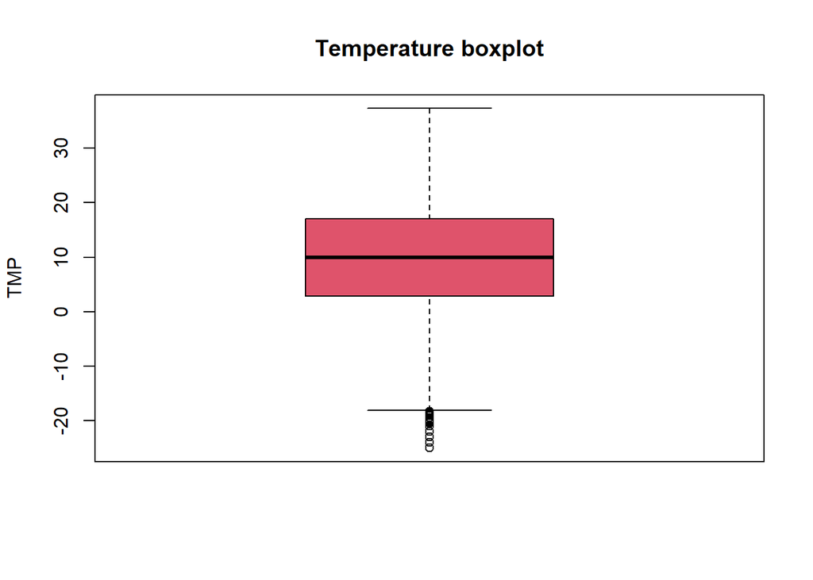

```r
# boxplot
boxplot(mandatory_data$TMP, col = 2, ylab = "TMP", main = "Temperature boxplot")
```

Z nasledujúcich boxplotov pre jednotlivé roky vidíme, že v roku 2017 boli namerané aj veľmi nízke hodnoty teploty. Naopak v roku 2014 má krabica boxplotu rozptyl najmenší, teda v tomto roku boli hodnoty dosť konzistentné oproti iným rokom.

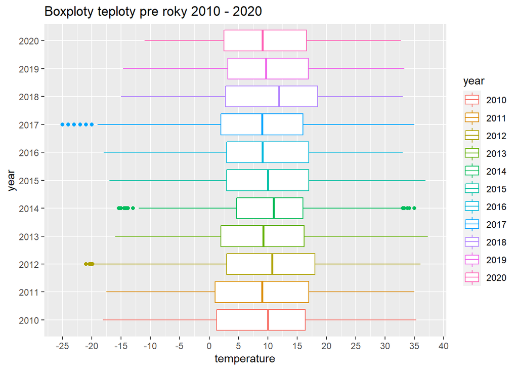

```r
df <- mandatory_data %>%
  dplyr::mutate(
    year = ymd_hms(DATE) %>%
      lubridate::year() %>%
      map_chr(~ as.character(.x))
  ) %>%
  dplyr::select(all_of(c('year', 'TMP')))

ggplot(data = df, aes(TMP, factor(year), colour = year)) +
  geom_boxplot() +
  labs(title = paste("Boxploty teploty pre roky 2010 - 2020"), x = "temperature", y = "year", fill = "year") +
  scale_x_continuous(breaks = seq(-40, 40, by = 5))
```

Grafy priemerných mesačných teplôt pre rok 2010 a 2020.

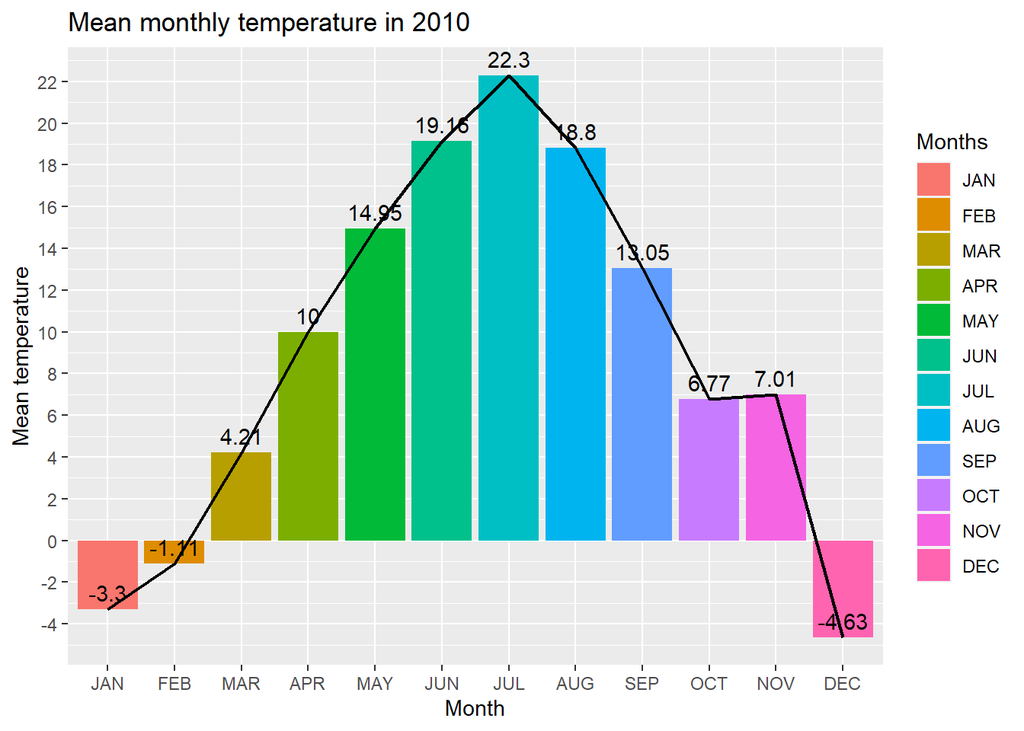

```r
mandatory_date_split <- mutate(mandatory_data, day = mday(DATE), month = month(DATE), year = year(DATE), hour = hour(DATE), min = minute(DATE))

# Select each 6 hours
# data_6_hours <- mandatory_date_split %>% filter(hour %in% c(0,6,12,18))

# # Select January 2010
# jan_2010 <- filter(data_6_hours, month == 1, year == 2010)
#
# ggplot(data = jan_2010) +
#   geom_line(aes(DATE, TMP), size = 0.8, col = 2) +
#   geom_point(mapping = aes(x = DATE, y = TMP), size = 1.3) +
#   labs(title = "Temperature 2010", y = "TMP")
#
# # Select January 2020
# jan_2020 <- filter(data_6_hours, month == 1, year == 2020)
#
# ggplot(data = jan_2020) +
#   geom_line(aes(DATE, TMP), size = 0.8, col = 2) +
#   geom_point(mapping = aes(x = DATE, y = TMP), size = 1.3) +
#   labs(title = "Temperature 2020", y = "TMP")


# Mean TMP 2010
mean_tmp_2010 <- filter(mandatory_date_split, year == 2010) %>% group_by(month) %>% summarise(mean = mean(TMP))

months <- c('JAN', 'FEB', 'MAR', 'APR', 'MAY', 'JUN', 'JUL', 'AUG', 'SEP', 'OCT', 'NOV', 'DEC')

ggplot(mean_tmp_2010, aes(x = factor(months,months), y = mean)) +
  geom_col(mapping = aes(fill = factor(months,months))) +
  geom_text(mapping = aes(label = round(mean,2)), vjust = -0.5) +
  geom_line(mapping = aes(x = month, y = mean), size = 0.8) +
  labs(title = paste("Mean monthly temperature in 2010"), x = "Month", y = "Mean temperature",
       fill = "Months") +
  scale_y_continuous(breaks = seq(-10, 30, by = 2))
```

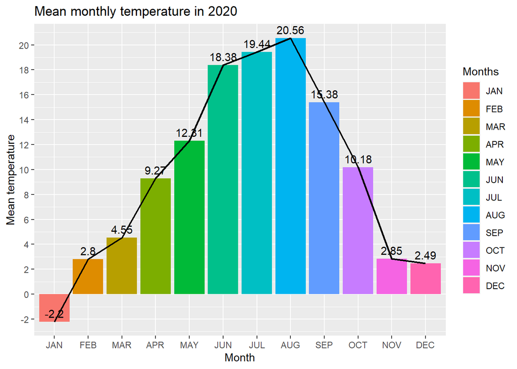

```r
# Mean TMP 2020
mean_tmp_2020 <- filter(mandatory_date_split, year == 2020) %>% group_by(month) %>% summarise(mean = mean(TMP))

ggplot(mean_tmp_2020, aes(x = factor(months,months), y = mean)) +
  geom_col(mapping = aes(fill = factor(months,months))) +
  geom_text(mapping = aes(label = round(mean,2)), vjust = -0.5) +
  geom_line(mapping = aes(x = month, y = mean), size = 0.8) +
  labs(title = paste("Mean monthly temperature in 2020"), x = "Month", y = "Mean temperature",
       fill = "Months") +
  scale_y_continuous(breaks = seq(-10, 30, by = 2))
```

Graf priemerných ročných teplôt pre roky 2010 - 2020. Vidíme, že najnižšia priemerná teplota bola v roku 2017 a najvyššia v roku 2018. Celkovo môžme vidieť mierne zvýšenie priemerných teplôt v porovnaní s rokmi 2010 a 2011.

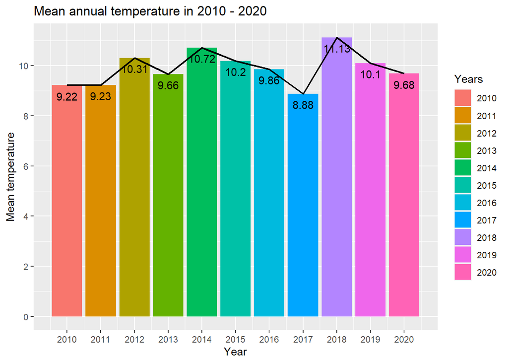

```r
# Mean TMP by year
mean_yr_tmp <- mandatory_date_split %>% group_by(year) %>% summarise(mean = mean(na.omit(TMP)))

ggplot(mean_yr_tmp, aes(x = year, y = mean)) +
  geom_col(mapping = aes(fill = factor(year,year))) +
  geom_text(mapping = aes(label = round(mean,2)), vjust = 1.8) +
  geom_line(mapping = aes(x = year, y = mean), size = 0.8) +
  labs(title = paste("Mean annual temperature in 2010 - 2020"), x = "Year", y = "Mean temperature",
       fill = "Years")  +
  scale_y_continuous(breaks = seq(0, 30, by = 2)) +
  scale_x_continuous(breaks = seq(2010, 2020, by = 1))
```

**Histogram**

Na histograme vidíme početnosti jednotlivých hodnôt teploty. Najpočetnejšie sú hodnoty medzi 0 - 20°C. Rozdelenie dát sa podobá normálnemu rozdeleniu. Hodnoty sú symetrické okolo mediánu.

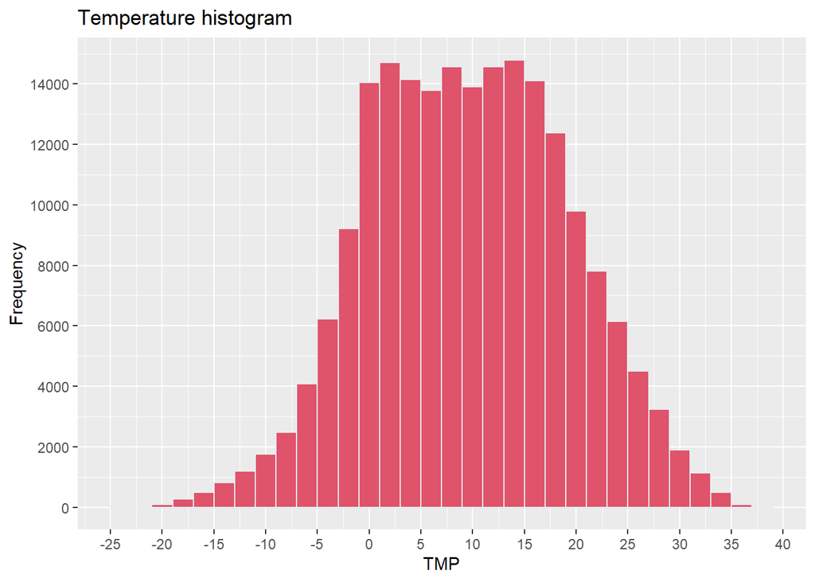

```r
# histogram
ggplot(mandatory_data, aes(x = TMP)) +
  geom_histogram(bins = 40, binwidth = 2, fill = 2, color = "#e9ecef") +
  labs(title = paste("Temperature histogram")) +
  xlab("TMP") +
  ylab("Frequency") +
  scale_x_continuous(breaks = seq(-40, 40, by = 5)) +
  scale_y_continuous(breaks = seq(0, 20000, by = 2000))
```

**Graf hustoty**

Graf hustoty slúži na porovnanie priebehu hustoty pravdepodobnosti normálneho rozdelenia (zelená čiara) a odhadu hustoty vypočítaného z namernaých hodnôt teploty (červená čiara). Čiary nie sú rovnaké, vrch rozdelenia je mierne zvlnený oproti normálnemu rozdeleniu. Modrá reprušovaná čiare predstavuje priemernú teplotu. Krivka teploty je viac plochá ako krivka normálneho rozdelenia, o čom svedčí aj hodnota špicatosti, ktorá je o niečo nižšia ako hodnota špicatosti normálneho rozdelenia. Z grafu vidno aj vrchol - najčastejšiu hodnotu 1 a niekoľko menších vrcholov v okolí hodnoty 8 a 15..

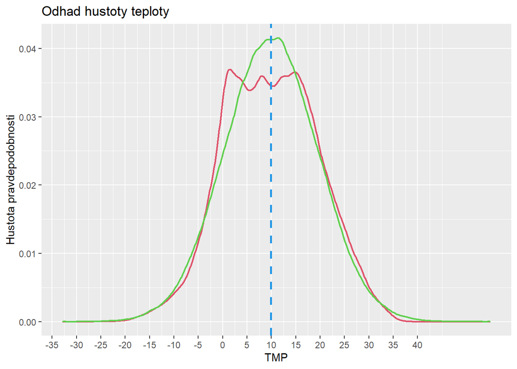

```r
# denisty plot
# data z normalneho rozdelenia
data_norm <- data.frame(dens = c(rnorm(length(na.omit(mandatory_data$TMP)), mean(mandatory_data$TMP, na.rm = T), sd(mandatory_data$TMP, na.rm = T))))

# porovnanie hodnot normalneho rozdelenia a TMP
ggplot(mandatory_data, aes(x = TMP),color = 3) +
  geom_density(color = 2, size = 0.8) +
  geom_density(data_norm, mapping = aes(x = dens), color = 3, size = 0.8) +
  geom_vline(aes(xintercept = mean(TMP, na.rm = T)),
            color = 4, linetype = "dashed", size = 1) +
  scale_x_continuous(breaks = seq(-40, 40, by = 5)) +
  labs(title = paste("Odhad hustoty teploty")) +
  xlab("TMP") +
  ylab("Hustota pravdepodobnosti")
```

**Husľový graf**

Husľový graf doplnený o hlavné kvartily zobrazuje rozdelenie hustoty, pričom aj podľa tohto grafu vidíme, že ide o normálne rozdelenie. Dáta sú najpočetnejšie v strede približne okolo hodnoty 1. a 3. kvartilu a smerom k vyšším, resp. nižším hodnotám sa ich hustota zmenšuje.

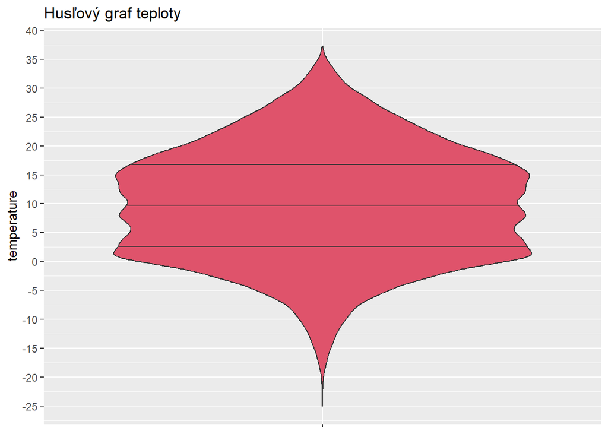

```r
# violin plot
df <- mandatory_data %>%
  dplyr::select('TMP') %>%
  tidyr::gather(key = 'label', value = 'tmp')

ggplot(data = df, aes(factor(label), tmp, fill = tmp)) +
  geom_violin(draw_quantiles = c(0.25, 0.5, 0.75), fill = 2) +
  labs(title = paste("Husľový graf teploty"), y = "temperature", fill = "temperature") +
  theme(axis.title.x = element_blank()) +
  theme(axis.text.x = element_blank()) +
  scale_y_continuous(breaks = seq(-40, 40, by = 5))
```

Z nasledujúcich grafov vidíme rozdelenie hustoty pre jednotlivé roky. V roku 2017 boli dáta najmenej konzistentné a obsahujú viac nízkych hodnôt ako po iné roky.

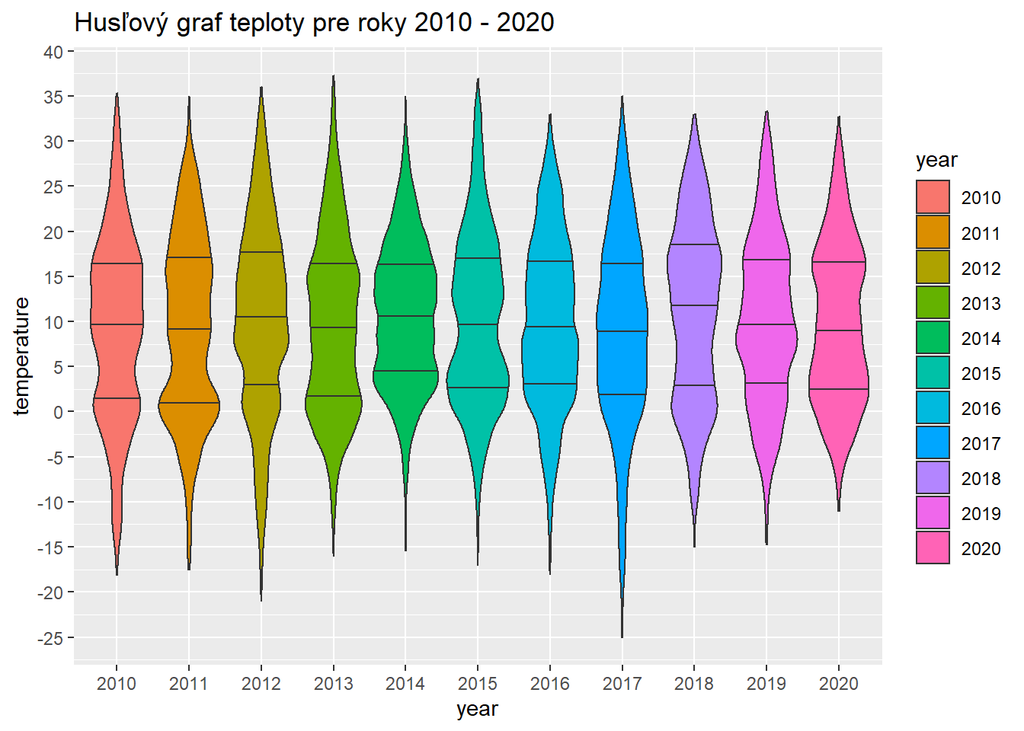

```r
df <- mandatory_data %>%
  dplyr::mutate(
    year = ymd_hms(DATE) %>%
      lubridate::year() %>%
      map_chr(~ as.character(.x))
  ) %>%
  dplyr::select(all_of(c('year', 'TMP')))

ggplot(data = df, aes(factor(year), TMP, fill = year)) +
  geom_violin(draw_quantiles=c(0.25, 0.5, 0.75)) +
  labs(title = paste("Husľový graf teploty pre roky 2010 - 2020"), x = "year", y = "temperature", fill = "year") +
  scale_y_continuous(breaks = seq(-40, 40, by = 5))
```

**Graf rozptýlenia**

Na osi x sú vynesené namerané hodnoty teploty a os y reprezentuje jednotlivé roky. Vidíme, že rozloženie dát je najhustejšie medzi hodnotami 0 - 20. Čím nižšia je hodnota teploty tým sa aj počet nameraných hodnôt znižuje, podobne aj pri vyokých teplotách. Ďalej vidíme, že v roku 2017 bola pravdepodobne veľmi chladná zima, pretože v tomto roku teplota dosahuje najnižšie hodnoty (mínus 20°C až mínus 25°C). Naopak v roku 2020 je len veľmi málo nízkych hodnôt (maximálne po mínus 10°C). V roku 2017 sú merané iba celočíselné hodnoty teploty.

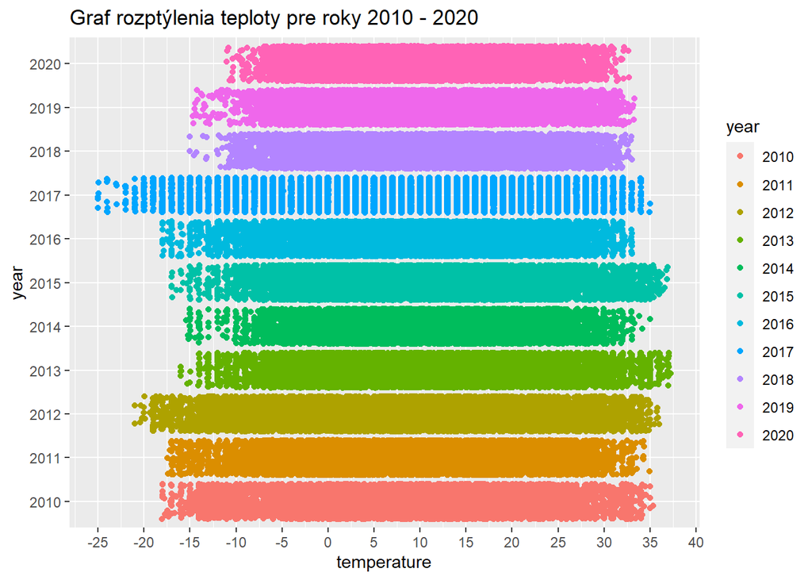

```r
df <- mandatory_data %>%
  dplyr::mutate(
    year = ymd_hms(DATE) %>%
      lubridate::year() %>%
      map_chr(~ as.character(.x))
  ) %>%
  dplyr::select(all_of(c('year', 'TMP')))

ggplot(data = df, aes( TMP,factor(year), colour=year)) +
  geom_jitter() +
  labs(title = paste("Graf rozptýlenia teploty pre roky 2010 - 2020"), x = "temperature", y = "year", fill = "year") +
  scale_x_continuous(breaks = seq(-40, 40, by = 5))
```

**Q-Q graf**

Graf zobrazuje odchýlku empirického od teoretického normálneho rozdelenia. Empirické rozdelenie je rozdelenie nameraných hodnôt teploty. Body ležia veľmi blízko priamky, odchyľujú sa len body v oblasti horných a dolných kvantilov, teda rozdelenie hodnôt teploty je podobné normálnemu rozdeleniu.

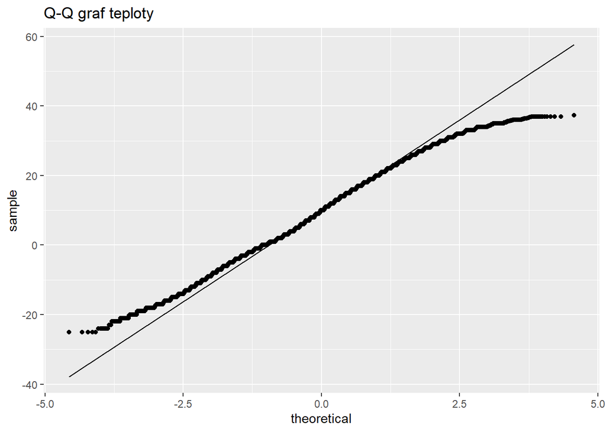

```r
# QQ plot
ggplot(data = mandatory_data, aes(sample = TMP)) +
  stat_qq() +
  stat_qq_line() +
  labs(title = paste("Q-Q graf teploty"))
```

**Graf polosum**

Z grafu polosum vidno, že hodnoty sú takmer symetrické okolo mediánu - hodnoty 10. Mierne sa odchyľujú len krajné hodnoty (veľmi nízke a veľmi vysoké).

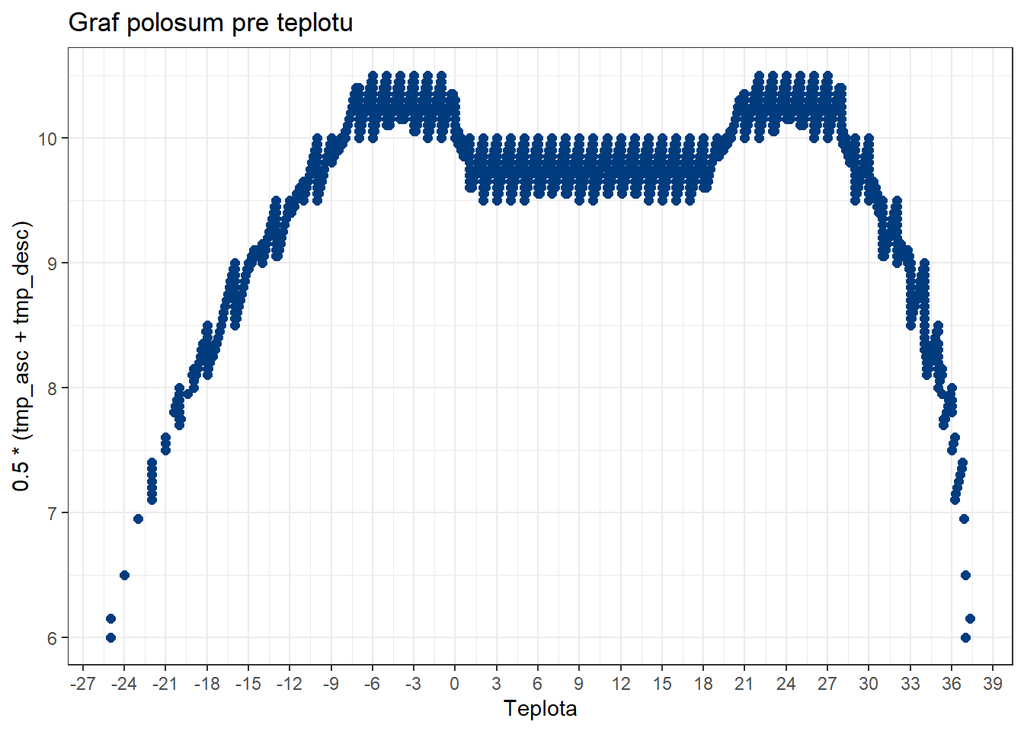

```r
# polosum
tmp <- mandatory_data$TMP
tmp_asc <- sort(tmp, decreasing = FALSE)
tmp_desc <- sort(tmp, decreasing = TRUE)

ggplot(data.frame(tmp_asc), aes(x = tmp_asc, y = 0.5*(tmp_asc+tmp_desc))) +
  geom_point(size = 2, color = "#013c7f") +
  scale_x_continuous(breaks = seq(-30, 40, by = 3)) +
  labs(title = "Graf polosum pre teplotu", x = "Teplota") +
  theme_bw()
```